# A1 Relative Prevalence of RRP

Gerko Vink

# Packages used

For this document we use the following packages

```r
library(dplyr)    # Data manipulation
library(mice)     # Data imputation
library(magrittr) # Pipes
library(purrr)    # Functional programming
library(haven)    # Import data
library(DT)       # Interactive tables
library(ggplot2)  # Plotting device
library(reshape2) # Data shaping
library(labelled) # Advanced labelling
```

# Load the data

```r
load(file = "../Workspaces/3. Data imputation.Rdata")
load(file = "../Workspaces/2. Data inspection.Rdata")
```

# RRP

First, we create an indicator for all RRP

```r
RRP_set <- names(raw_data[86:107])[c(1, 2, 4, 6, 9, 12, 15, 16, 17, 19, 21 )]
```

## Tables and plots

### Overall

```r
mice::complete(imp, 1) %>% #RRP has no missings -so use 1st imputed set
  select(all_of(RRP_set)) %>%
  sapply(table)
```

```
##    RP1  RP2  RP4  RP6  RP9 RP12 RP15 RP16 RP17 RP19 RP21
## 0  886 3389  466  917  696 2647  754  707  233 1879  299
## 1   70  209   47  134  315 1278   55  251   10  821   12
## 2   26   60  263  271  604  376  134  226   11  622   47
## 3   33   57  428  376  774  271  209  298    9  536  102
## 4   78  138  420  694  978  457  305  896   35  626  211
## 5  190  213  875 1222 1344  524  769 1406  246  800  856
## 6  638  608 1885 1737 1405  630 1766 1687 1555  794 2241
## 7 4892 2139 2429 1462  697  630 2821 1342 4714  735 3045
```

Zero indicates not applicable

Then we calculate the proportional table

```r
p_tab <- function(x){prop.table(table(x)) %>% round(3)}
mice::complete(imp, 1) %>% #RRP has no missings -so use 1st imputed set
  select(all_of(RRP_set)) %>%
  sapply(p_tab) %>%
  round(3)
```

```
##     RP1   RP2   RP4   RP6   RP9  RP12  RP15  RP16  RP17  RP19  RP21
## 0 0.130 0.497 0.068 0.135 0.102 0.389 0.111 0.104 0.034 0.276 0.044
## 1 0.010 0.031 0.007 0.020 0.046 0.188 0.008 0.037 0.001 0.121 0.002
## 2 0.004 0.009 0.039 0.040 0.089 0.055 0.020 0.033 0.002 0.091 0.007
## 3 0.005 0.008 0.063 0.055 0.114 0.040 0.031 0.044 0.001 0.079 0.015
## 4 0.011 0.020 0.062 0.102 0.144 0.067 0.045 0.132 0.005 0.092 0.031
## 5 0.028 0.031 0.128 0.179 0.197 0.077 0.113 0.206 0.036 0.117 0.126
## 6 0.094 0.089 0.277 0.255 0.206 0.092 0.259 0.248 0.228 0.117 0.329
## 7 0.718 0.314 0.357 0.215 0.102 0.092 0.414 0.197 0.692 0.108 0.447
```

Next, we create the stacked barplot.

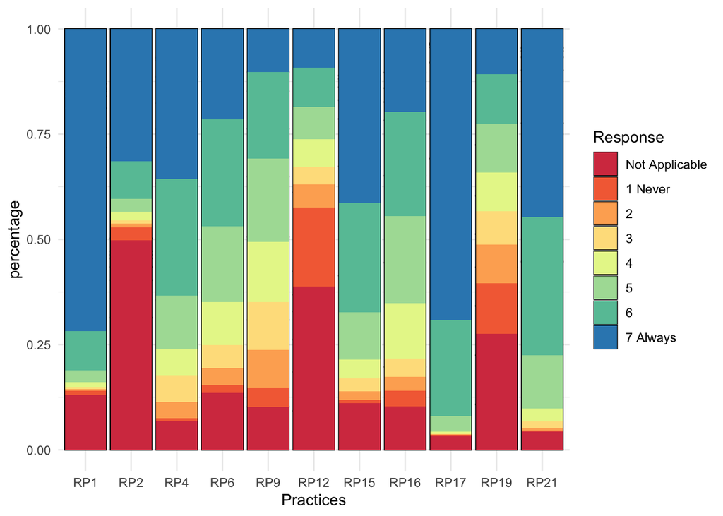

```r
mice::complete(imp, 1) %>% #RRP has no missings -so use 1st imputed set
  select(all_of(RRP_set)) %>%
  sapply(table) %>%
  melt(varnames = c("Response", "Practices")) %>%
  mutate(Response = factor(Response),
         percentage = value / (sum(value)/11),
         Response = recode(Response, `0` = "Not Applicable", `1` = "1 Never", `7` = "7 Always")) %>%
  ggplot(aes(x = Practices, y = percentage, fill = Response)) +
  geom_bar(stat = 'identity', position = "stack", colour="black") +
  geom_col(position = position_stack(reverse = TRUE)) +
  scale_fill_brewer(palette = "Spectral") +
  theme_minimal()
```

### By Disciplinary Field

First, we grab the info from `D2`

```r
raw_data$D2 %>% var_label
```

```
## [1] "D2: Which of the following is your main disciplinary field of research?"
```

```r
raw_data$D2 %>% val_labels
```

```
##   Social and Behavioral Sciences              Arts and Humanities
##                                1                                2
## Engineering and Natural Sciences     Biomedical and Life Sciences
##                                3                                4
```

Then we calculate a table for each of the labels in `D2`

```r
out <- mice::complete(imp, 1) %>%
  select(D2, RRP_set) %>%
  mutate(across(where(is.numeric), as.factor)) %>%
  group_by(D2) %>%
  group_map(~sapply(., table, simplify = TRUE))
```

```
## Note: Using an external vector in selections is ambiguous.
## ℹ Use `all_of(RRP_set)` instead of `RRP_set` to silence this message.
## ℹ See <https://tidyselect.r-lib.org/reference/faq-external-vector.html>.
```

```r
names(out) <- raw_data$D2 %>% val_labels %>% names
out
```

```
## $`Social and Behavioral Sciences`
##    RP1  RP2 RP4 RP6 RP9 RP12 RP15 RP16 RP17 RP19 RP21
## 0  297 1085 138 285 171  639  195  226   45  565   94
## 1   23   73  11  49  75  461   18  103    3  323    2
## 2    9   14  64  95 189  114   37   68    3  196   10
## 3   10   18 115 120 234   80   56   72    1  132   24
## 4   22   41 100 229 282  155   88  231    6  169   62
## 5   61   53 242 325 419  209  221  417   76  200  277
## 6  180  160 481 449 416  162  471  489  400  178  665
## 7 1363  521 814 413 179  145  879  359 1431  202  831
##
## $`Arts and Humanities`
##   RP1 RP2 RP4 RP6 RP9 RP12 RP15 RP16 RP17 RP19 RP21
## 0 195 332 138 175 165  431  240   73   19  430   45
## 1  10  14   0   8  36   82    5   35    1   37    1
```

[output cut: 28 more lines]

Then we calculate the proportional table

```r
p.out <- mice::complete(imp, 1) %>%
  select(D2, RRP_set) %>%
  mutate(across(where(is.numeric), as.factor)) %>%
  group_by(D2) %>%
  group_map(~sapply(., p_tab, simplify = TRUE))
names(p.out) <- names(out)
p.out
```

```
## $`Social and Behavioral Sciences`
##     RP1   RP2   RP4   RP6   RP9  RP12  RP15  RP16  RP17  RP19  RP21
## 0 0.151 0.552 0.070 0.145 0.087 0.325 0.099 0.115 0.023 0.288 0.048
## 1 0.012 0.037 0.006 0.025 0.038 0.235 0.009 0.052 0.002 0.164 0.001
## 2 0.005 0.007 0.033 0.048 0.096 0.058 0.019 0.035 0.002 0.100 0.005
## 3 0.005 0.009 0.059 0.061 0.119 0.041 0.028 0.037 0.001 0.067 0.012
## 4 0.011 0.021 0.051 0.117 0.144 0.079 0.045 0.118 0.003 0.086 0.032
## 5 0.031 0.027 0.123 0.165 0.213 0.106 0.112 0.212 0.039 0.102 0.141
## 6 0.092 0.081 0.245 0.228 0.212 0.082 0.240 0.249 0.204 0.091 0.338
## 7 0.694 0.265 0.414 0.210 0.091 0.074 0.447 0.183 0.728 0.103 0.423
##
## $`Arts and Humanities`
##     RP1   RP2   RP4   RP6   RP9  RP12  RP15  RP16  RP17  RP19  RP21
## 0 0.307 0.522 0.217 0.275 0.259 0.678 0.377 0.115 0.030 0.676 0.071
## 1 0.016 0.022 0.000 0.013 0.057 0.129 0.008 0.055 0.002 0.058 0.002
```

[output cut: 28 more lines]

And the plots

```
## $`Social and Behavioral Sciences`
```

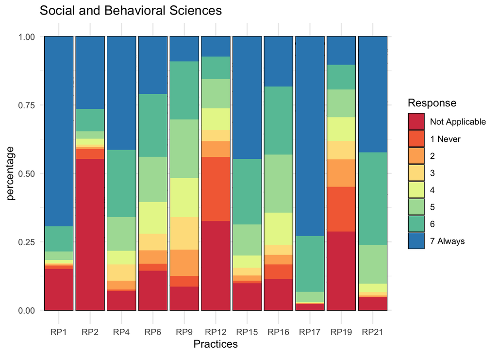

```
##
## $`Arts and Humanities`
```

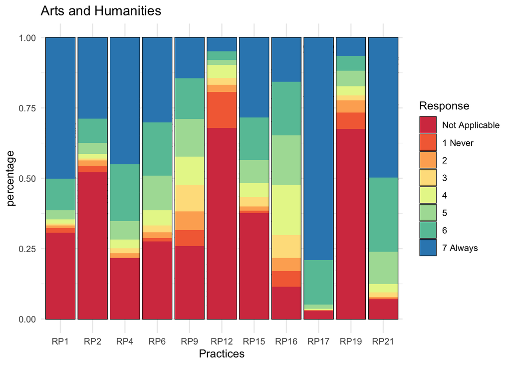

```
##
## $`Engineering and Natural Sciences`
```

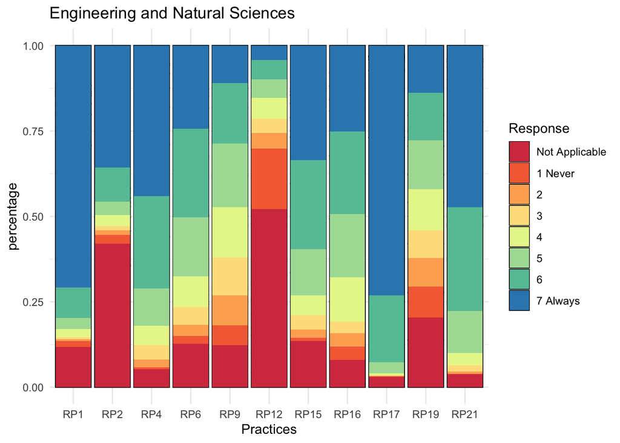

```
##
## $`Biomedical and Life Sciences`
```

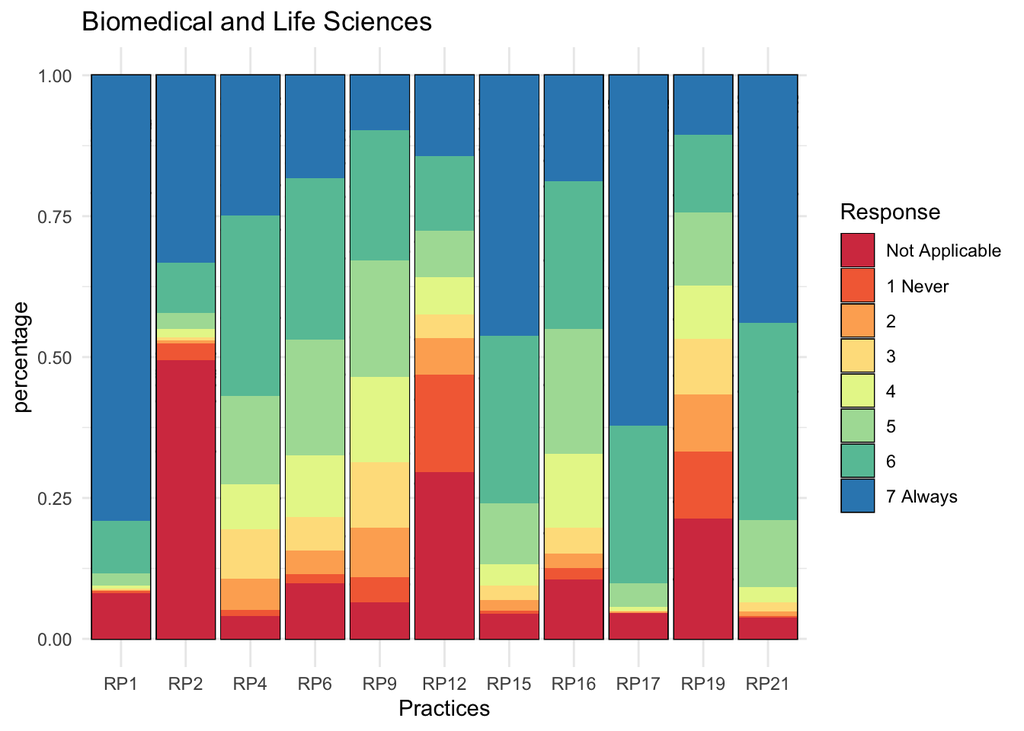

```r
barplotfun <- function(data){
  current <- sapply(out, function(x){identical(x, data)}) %>% which %>% names
  data %>%
    melt(varnames = c("Response", "Practices")) %>%
    mutate(Response = factor(Response),
           percentage = value / (sum(value)/11),
           Response = recode(Response, `0` = "Not Applicable", `1` = "1 Never", `7` = "7 Always")) %>%
    ggplot(aes(x = Practices, y = percentage, fill = Response)) +
    geom_bar(stat = 'identity', position = "stack", colour="black") +
    geom_col(position = position_stack(reverse = TRUE)) +
    scale_fill_brewer(palette = "Spectral") +
    theme_minimal() +
    ggtitle(current)
}
lapply(out, barplotfun)
```

### By academic rank

First, we grab the info from `D3`

```r
raw_data$D3 %>% var_label
```

```
## [1] "D3: Which academic rank do you belong to?"
```

```r
raw_data$D3 %>% val_labels
```

```
##                                                          PhD student or junior researcher
##                                                                                         1
## Postdoctoral researcher, Assistant Professor, Physician Researcher or Lecturer Researcher
##                                                                                         2
##                                                     Associate Professor or Full Professor
##                                                                                         3
##                                                                         None of the above
##                                                                                         4
```

Then we calculate a table for each of the labels in `D3`

```r
out <- mice::complete(imp, 1) %>%
  select(D3, RRP_set) %>%
  mutate(across(where(is.numeric), as.factor)) %>%
  group_by(D3) %>%
  group_map(~sapply(., table, simplify = TRUE))
names(out) <- raw_data$D3 %>% val_labels %>% names %>% .[1:3]
out
```

```
## $`PhD student or junior researcher`
##    RP1  RP2 RP4 RP6 RP9 RP12 RP15 RP16 RP17 RP19 RP21
## 0  488 1124 305 462 202  858  229  585  176  796  214
## 1   35   48  24  37  49  370   13  117    2  287    4
## 2   11   13 110  76 137   89   19   57    1  149   11
## 3   14   13 163 100 219   75   54   59    4  135   25
## 4   32   34 143 171 280  109   79  141   15  130   62
## 5   60   69 255 301 458  133  250  208  109  143  266
## 6  152  190 415 436 436  160  535  270  471  158  592
## 7 1221  522 598 430 232  219  834  576 1235  215  839
##
## $`Postdoctoral researcher, Assistant Professor, Physician Researcher or Lecturer Researcher`
##    RP1  RP2 RP4 RP6 RP9 RP12 RP15 RP16 RP17 RP19 RP21
## 0  228 1316 106 274 228 1028  253   97   37  617   54
## 1   21   97  20  64 108  555   20  100    6  365    8
```

[output cut: 17 more lines]

Then we calculate the proportional table

```r
p.out <- mice::complete(imp, 1) %>%
  select(D3, RRP_set) %>%
  mutate(across(where(is.numeric), as.factor)) %>%
  group_by(D3) %>%
  group_map(~sapply(., p_tab, simplify = TRUE))
names(p.out) <- names(out)
p.out
```

```
## $`PhD student or junior researcher`
##     RP1   RP2   RP4   RP6   RP9  RP12  RP15  RP16  RP17  RP19  RP21
## 0 0.242 0.558 0.152 0.230 0.100 0.426 0.114 0.291 0.087 0.395 0.106
## 1 0.017 0.024 0.012 0.018 0.024 0.184 0.006 0.058 0.001 0.143 0.002
## 2 0.005 0.006 0.055 0.038 0.068 0.044 0.009 0.028 0.000 0.074 0.005
## 3 0.007 0.006 0.081 0.050 0.109 0.037 0.027 0.029 0.002 0.067 0.012
## 4 0.016 0.017 0.071 0.085 0.139 0.054 0.039 0.070 0.007 0.065 0.031
## 5 0.030 0.034 0.127 0.150 0.228 0.066 0.124 0.103 0.054 0.071 0.132
## 6 0.076 0.094 0.206 0.217 0.217 0.079 0.266 0.134 0.234 0.078 0.294
## 7 0.607 0.259 0.297 0.214 0.115 0.109 0.414 0.286 0.614 0.107 0.417
##
## $`Postdoctoral researcher, Assistant Professor, Physician Researcher or Lecturer Researcher`
##     RP1   RP2   RP4   RP6   RP9  RP12  RP15  RP16  RP17  RP19  RP21
## 0 0.083 0.482 0.039 0.100 0.083 0.376 0.093 0.035 0.014 0.226 0.020
## 1 0.008 0.035 0.007 0.023 0.040 0.203 0.007 0.037 0.002 0.134 0.003
```

[output cut: 17 more lines]

And the plots

```
## $`PhD student or junior researcher`
```

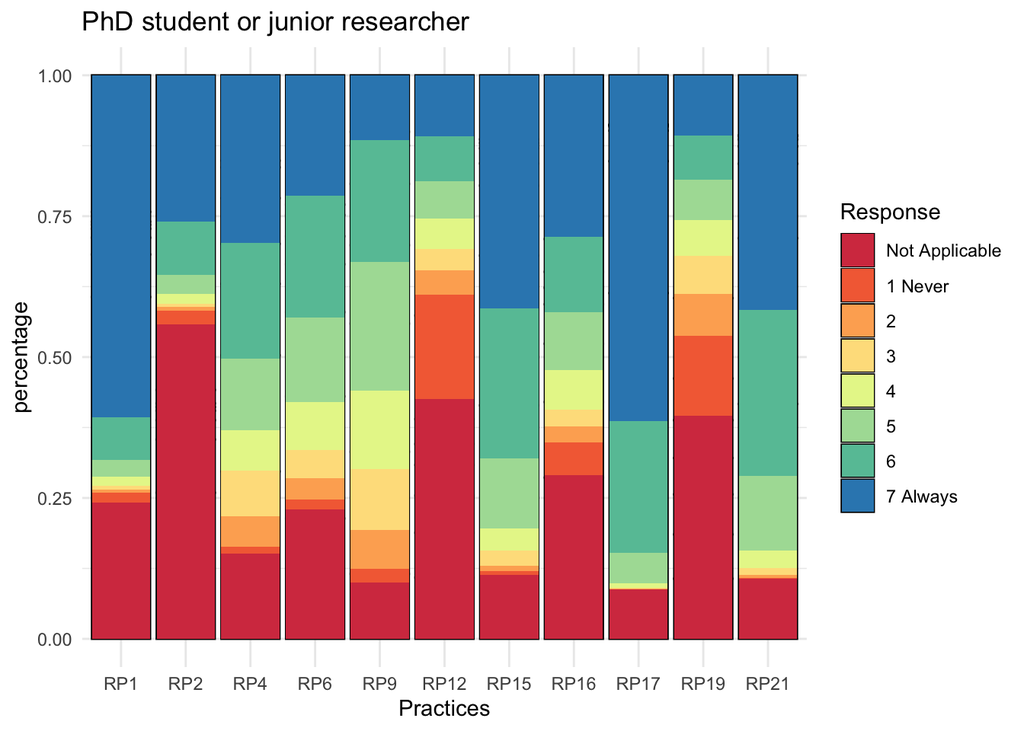

```
##
## $`Postdoctoral researcher, Assistant Professor, Physician Researcher or Lecturer Researcher`
```

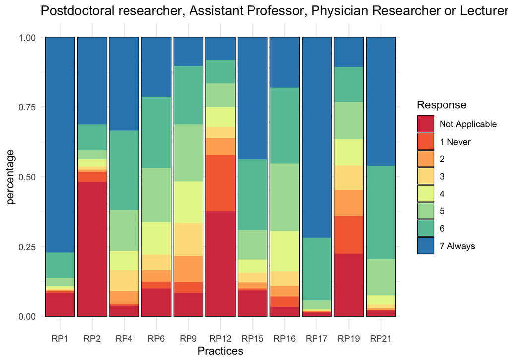

```
##
## $`Associate Professor or Full Professor`
```

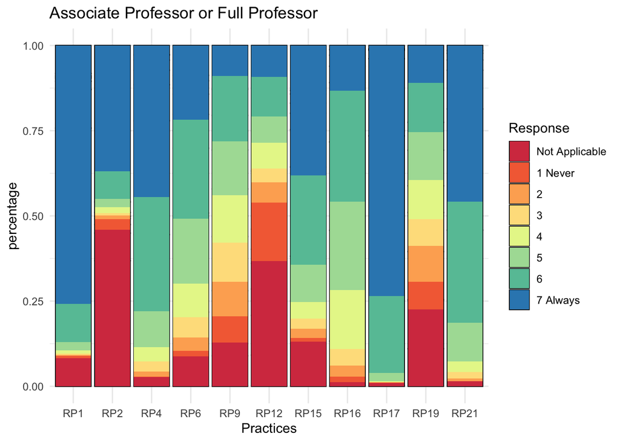

```r
lapply(out, barplotfun)
```

### By gender identification

First, we grab the info from `D4`

```r
raw_data$D4 %>% var_label
```

```
## [1] "D4: What is your gender?"
```

```r
raw_data$D4 %>% val_labels
```

```
##                          Female                            Male
##                               1                               2
## Other / Do not wish to disclose
##                               3
```

Then we calculate a table for each of the labels in `D4`

```r
out <- mice::complete(imp, 1) %>%
  select(D4, RRP_set) %>%
  mutate(across(where(is.numeric), as.factor)) %>%
  group_by(D4) %>%
  group_map(~sapply(., table, simplify = TRUE))
names(out) <- raw_data$D4 %>% val_labels %>% names
out
```

```
## $Female
##    RP1  RP2 RP4 RP6 RP9 RP12 RP15 RP16 RP17 RP19 RP21
## 0  429 1631 248 453 275 1120  293  423  145  941  173
## 1   30   68  25  40  86  517   17  111    5  418    3
## 2    7   25 139 127 212  163   47   94    9  306   21
## 3   16   28 258 189 321  139   78  126    4  259   34
## 4   31   54 229 339 438  209  133  354   18  250   84
## 5   80   82 428 540 677  246  340  575  118  308  382
## 6  281  255 778 732 675  297  773  714  692  270  963
## 7 2134  865 903 588 324  317 1327  611 2017  256 1348
##
## $Male
##    RP1  RP2  RP4 RP6 RP9 RP12 RP15 RP16 RP17 RP19 RP21
## 0  442 1709  211 441 407 1470  436  273   85  898  123
## 1   38  140   22  90 223  739   36  136    5  390    8
```

[output cut: 17 more lines]

Then we calculate the proportional table

```r
p.out <- mice::complete(imp, 1) %>%
  select(D4, RRP_set) %>%
  mutate(across(where(is.numeric), as.factor)) %>%
  group_by(D4) %>%
  group_map(~sapply(., p_tab, simplify = TRUE))
names(p.out) <- names(out)
p.out
```

```
## $Female
##     RP1   RP2   RP4   RP6   RP9  RP12  RP15  RP16  RP17  RP19  RP21
## 0 0.143 0.542 0.082 0.151 0.091 0.372 0.097 0.141 0.048 0.313 0.058
## 1 0.010 0.023 0.008 0.013 0.029 0.172 0.006 0.037 0.002 0.139 0.001
## 2 0.002 0.008 0.046 0.042 0.070 0.054 0.016 0.031 0.003 0.102 0.007
## 3 0.005 0.009 0.086 0.063 0.107 0.046 0.026 0.042 0.001 0.086 0.011
## 4 0.010 0.018 0.076 0.113 0.146 0.069 0.044 0.118 0.006 0.083 0.028
## 5 0.027 0.027 0.142 0.180 0.225 0.082 0.113 0.191 0.039 0.102 0.127
## 6 0.093 0.085 0.259 0.243 0.224 0.099 0.257 0.237 0.230 0.090 0.320
## 7 0.709 0.288 0.300 0.195 0.108 0.105 0.441 0.203 0.671 0.085 0.448
##
## $Male
##     RP1   RP2   RP4   RP6   RP9  RP12  RP15  RP16  RP17  RP19  RP21
## 0 0.120 0.463 0.057 0.120 0.110 0.398 0.118 0.074 0.023 0.243 0.033
## 1 0.010 0.038 0.006 0.024 0.060 0.200 0.010 0.037 0.001 0.106 0.002
```

[output cut: 17 more lines]

And the plots

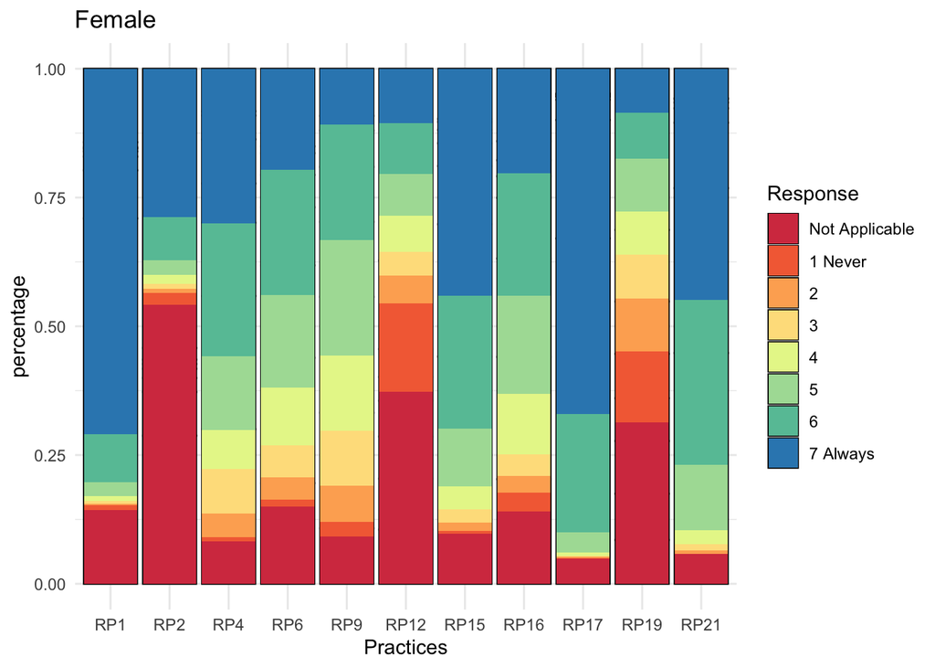

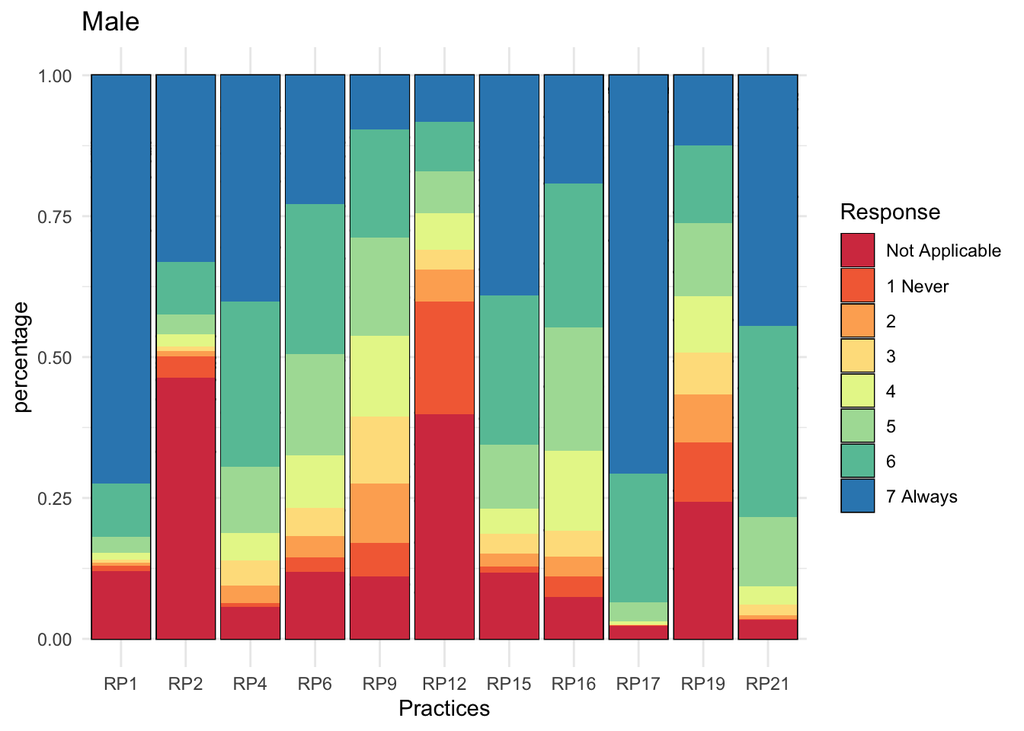

```
##
## $`Other / Do not wish to disclose`
```

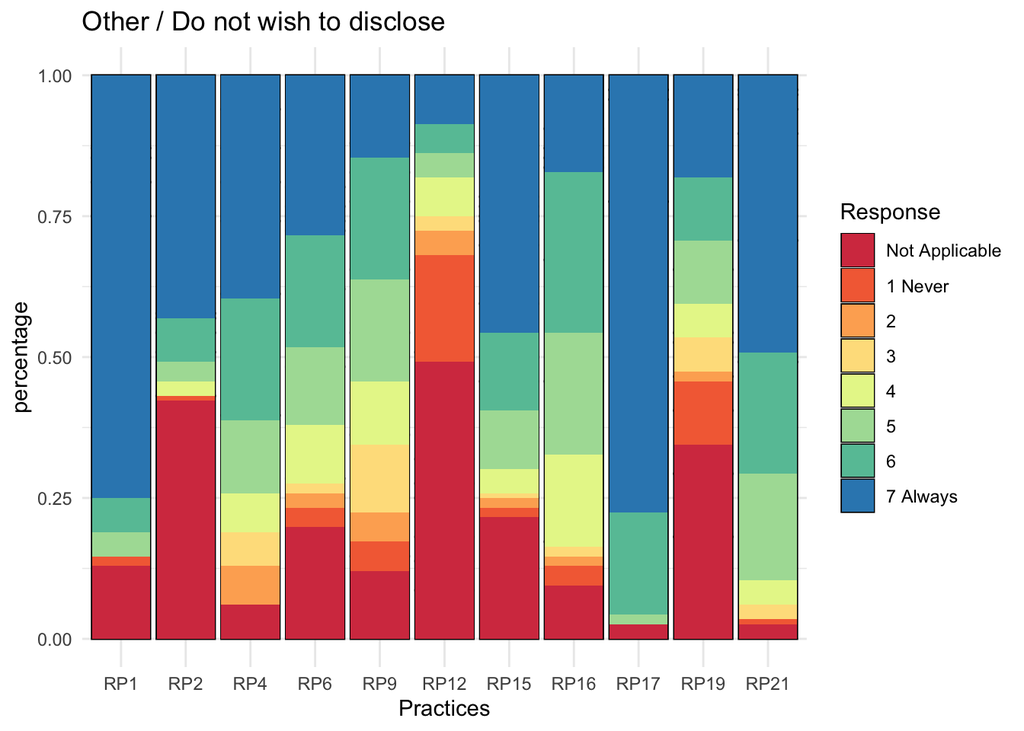

```r
lapply(out, barplotfun)
```

### By empirical research engagement

First, we grab the info from `D5`

```r
raw_data$D5 %>% var_label
```

```
## [1] "D5: Were you engaged in empirical research in the last three years?"
```

```r
raw_data$D5 %>% val_labels
```

```
## Yes  No
##   1   2
```

Then we calculate a table for each of the labels in `D5`

```r
out <- mice::complete(imp, 1) %>%
  select(D5, RRP_set) %>%
  mutate(across(where(is.numeric), as.factor)) %>%
  group_by(D5) %>%
  group_map(~sapply(., table, simplify = TRUE))
names(out) <- raw_data$D5 %>% val_labels %>% names
out
```

```
## $Yes
##    RP1  RP2  RP4  RP6  RP9 RP12 RP15 RP16 RP17 RP19 RP21
## 0  673 3038  316  684  493 2132  403  599  194 1466  220
## 1   48  191   41  123  263 1198   46  200    9  791    9
## 2   16   52  250  260  552  356  120  181    9  589   42
## 3   29   47  408  360  719  258  185  262    8  511   98
## 4   64  124  390  648  904  422  284  787   30  588  185
## 5  166  183  817 1136 1231  506  707 1281  220  748  782
## 6  578  533 1753 1605 1303  609 1659 1562 1415  730 2043
## 7 4509 1915 2108 1267  618  602 2679 1211 4198  660 2704
##
## $No
##   RP1 RP2 RP4 RP6 RP9 RP12 RP15 RP16 RP17 RP19 RP21
## 0 213 351 150 233 203  515  351  108   39  413   79
## 1  22  18   6  11  52   80    9   51    1   30    3
## 2  10   8  13  11  52   20   14   45    2   33    5
## 3   4  10  20  16  55   13   24   36    1   25    4
## 4  14  14  30  46  74   35   21  109    5   38   26
## 5  24  30  58  86 113   18   62  125   26   52   74
## 6  60  75 132 132 102   21  107  125  140   64  198
## 7 383 224 321 195  79   28  142  131  516   75  341
```

Then we calculate the proportional table

```r
p.out <- mice::complete(imp, 1) %>%
  select(D5, RRP_set) %>%
  mutate(across(where(is.numeric), as.factor)) %>%
  group_by(D5) %>%
  group_map(~sapply(., p_tab, simplify = TRUE))
names(p.out) <- names(out)
p.out
```

```
## $Yes
##     RP1   RP2   RP4   RP6   RP9  RP12  RP15  RP16  RP17  RP19  RP21
## 0 0.111 0.499 0.052 0.112 0.081 0.350 0.066 0.098 0.032 0.241 0.036
## 1 0.008 0.031 0.007 0.020 0.043 0.197 0.008 0.033 0.001 0.130 0.001
## 2 0.003 0.009 0.041 0.043 0.091 0.059 0.020 0.030 0.001 0.097 0.007
## 3 0.005 0.008 0.067 0.059 0.118 0.042 0.030 0.043 0.001 0.084 0.016
## 4 0.011 0.020 0.064 0.107 0.149 0.069 0.047 0.129 0.005 0.097 0.030
## 5 0.027 0.030 0.134 0.187 0.202 0.083 0.116 0.211 0.036 0.123 0.129
## 6 0.095 0.088 0.288 0.264 0.214 0.100 0.273 0.257 0.233 0.120 0.336
## 7 0.741 0.315 0.347 0.208 0.102 0.099 0.440 0.199 0.690 0.108 0.445
##
## $No
##     RP1   RP2   RP4   RP6   RP9  RP12  RP15  RP16  RP17  RP19  RP21
## 0 0.292 0.481 0.205 0.319 0.278 0.705 0.481 0.148 0.053 0.566 0.108
## 1 0.030 0.025 0.008 0.015 0.071 0.110 0.012 0.070 0.001 0.041 0.004
## 2 0.014 0.011 0.018 0.015 0.071 0.027 0.019 0.062 0.003 0.045 0.007
## 3 0.005 0.014 0.027 0.022 0.075 0.018 0.033 0.049 0.001 0.034 0.005
## 4 0.019 0.019 0.041 0.063 0.101 0.048 0.029 0.149 0.007 0.052 0.036
## 5 0.033 0.041 0.079 0.118 0.155 0.025 0.085 0.171 0.036 0.071 0.101
## 6 0.082 0.103 0.181 0.181 0.140 0.029 0.147 0.171 0.192 0.088 0.271
## 7 0.525 0.307 0.440 0.267 0.108 0.038 0.195 0.179 0.707 0.103 0.467
```

And the plots

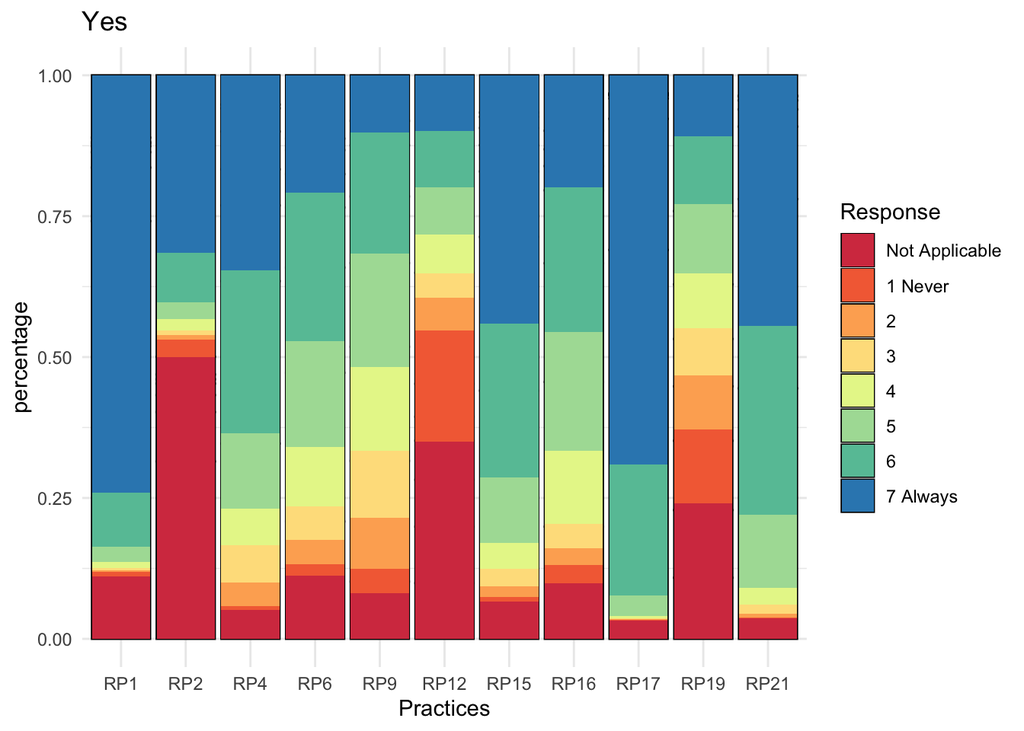

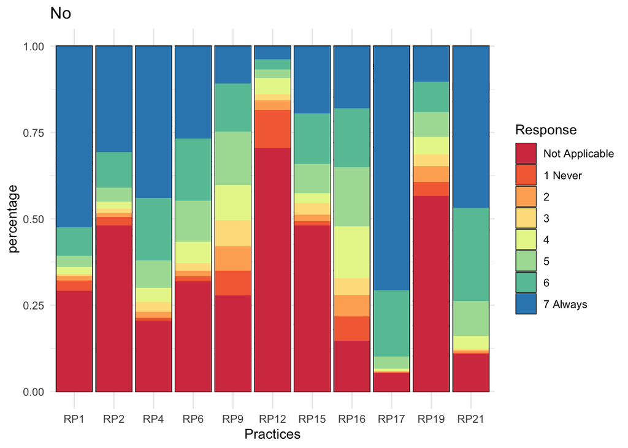

```r
lapply(out, barplotfun)
```

### By institutional support

First, we grab the info from `Group`

```r
raw_data$Group %>% var_label
```

```
## [1] "Group"
```

```r
raw_data$Group %>% val_labels
```

```
##     Joining group Non-joining group
##                 1                 2
```

Then we calculate a table for each of the labels in `Group`

```r
out <- mice::complete(imp, 1) %>%
  select(Group, RRP_set) %>%
  mutate(across(where(is.numeric), as.factor)) %>%
  group_by(Group) %>%
  group_map(~sapply(., table, simplify = TRUE))
names(out) <- raw_data$Group %>% val_labels %>% names
out
```

```
## $`Joining group`
##    RP1  RP2  RP4 RP6 RP9 RP12 RP15 RP16 RP17 RP19 RP21
## 0  483 1706  250 474 318 1183  360  439  145 1001  182
## 1   30   89   30  68 135  563   23  140    6  415    7
## 2   12   28  145 142 272  171   53  112    8  312   16
## 3   11   21  247 177 380  129   90  151    5  262   49
## 4   32   59  218 352 482  213  147  422   22  264  101
## 5   81   91  436 580 685  295  358  630  120  341  441
## 6  290  284  888 828 703  338  859  763  758  366 1052
## 7 2331  992 1056 649 295  378 1380  613 2206  309 1422
##
## $`Non-joining group`
##    RP1  RP2  RP4 RP6 RP9 RP12 RP15 RP16 RP17 RP19 RP21
## 0  403 1683  216 443 378 1464  394  268   88  878  117
## 1   40  120   17  66 180  715   32  111    4  406    5
## 2   14   32  118 129 332  205   81  114    3  310   31
## 3   22   36  181 199 394  142  119  147    4  274   53
## 4   46   79  202 342 496  244  158  474   13  362  110
## 5  109  122  439 642 659  229  411  776  126  459  415
## 6  348  324  997 909 702  292  907  924  797  428 1189
## 7 2561 1147 1373 813 402  252 1441  729 2508  426 1623
```

Then we calculate the proportional table

```r
p.out <- mice::complete(imp, 1) %>%
  select(Group, RRP_set) %>%
  mutate(across(where(is.numeric), as.factor)) %>%
  group_by(Group) %>%
  group_map(~sapply(., p_tab, simplify = TRUE))
names(p.out) <- names(out)
p.out
```

```
## $`Joining group`
##     RP1   RP2   RP4   RP6   RP9  RP12  RP15  RP16  RP17  RP19  RP21
## 0 0.148 0.522 0.076 0.145 0.097 0.362 0.110 0.134 0.044 0.306 0.056
## 1 0.009 0.027 0.009 0.021 0.041 0.172 0.007 0.043 0.002 0.127 0.002
## 2 0.004 0.009 0.044 0.043 0.083 0.052 0.016 0.034 0.002 0.095 0.005
## 3 0.003 0.006 0.076 0.054 0.116 0.039 0.028 0.046 0.002 0.080 0.015
## 4 0.010 0.018 0.067 0.108 0.147 0.065 0.045 0.129 0.007 0.081 0.031
## 5 0.025 0.028 0.133 0.177 0.209 0.090 0.109 0.193 0.037 0.104 0.135
## 6 0.089 0.087 0.272 0.253 0.215 0.103 0.263 0.233 0.232 0.112 0.322
## 7 0.713 0.303 0.323 0.198 0.090 0.116 0.422 0.187 0.675 0.094 0.435
##
## $`Non-joining group`
##     RP1   RP2   RP4   RP6   RP9  RP12  RP15  RP16  RP17  RP19  RP21
## 0 0.114 0.475 0.061 0.125 0.107 0.413 0.111 0.076 0.025 0.248 0.033
## 1 0.011 0.034 0.005 0.019 0.051 0.202 0.009 0.031 0.001 0.115 0.001
## 2 0.004 0.009 0.033 0.036 0.094 0.058 0.023 0.032 0.001 0.087 0.009
## 3 0.006 0.010 0.051 0.056 0.111 0.040 0.034 0.041 0.001 0.077 0.015
## 4 0.013 0.022 0.057 0.097 0.140 0.069 0.045 0.134 0.004 0.102 0.031
## 5 0.031 0.034 0.124 0.181 0.186 0.065 0.116 0.219 0.036 0.130 0.117
## 6 0.098 0.091 0.281 0.257 0.198 0.082 0.256 0.261 0.225 0.121 0.336
## 7 0.723 0.324 0.388 0.229 0.113 0.071 0.407 0.206 0.708 0.120 0.458
```

And the plots

```
## $`Joining group`
```

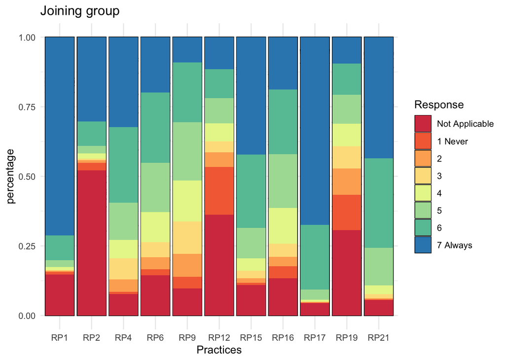

```
##
## $`Non-joining group`
```

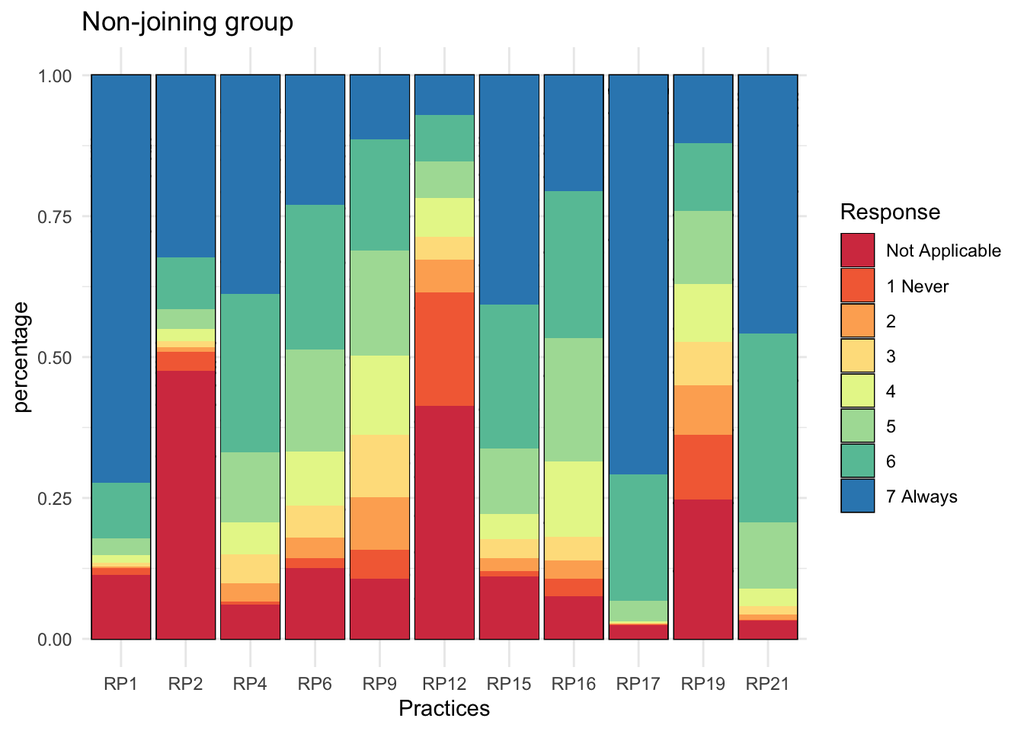

```r
lapply(out, barplotfun)
```

# RRP without `Not Applicable`’s

## Tables and plots

### Overall

```r
mice::complete(imp, 1) %>% #RRP has no missings -so use 1st imputed set
  select(all_of(RRP_set)) %>%
  na_if(0) %>%
  sapply(table)
```

```
##    RP1  RP2  RP4  RP6  RP9 RP12 RP15 RP16 RP17 RP19 RP21
## 1   70  209   47  134  315 1278   55  251   10  821   12
## 2   26   60  263  271  604  376  134  226   11  622   47
## 3   33   57  428  376  774  271  209  298    9  536  102
## 4   78  138  420  694  978  457  305  896   35  626  211
## 5  190  213  875 1222 1344  524  769 1406  246  800  856
## 6  638  608 1885 1737 1405  630 1766 1687 1555  794 2241
## 7 4892 2139 2429 1462  697  630 2821 1342 4714  735 3045
```

Zero indicates not applicable

Then we calculate the proportional table

```r
p_tab <- function(x){prop.table(table(x)) %>% round(3)}
mice::complete(imp, 1) %>% #RRP has no missings -so use 1st imputed set
  select(all_of(RRP_set)) %>%
  na_if(0) %>%
  sapply(p_tab) %>%
  round(3)
```

```
##     RP1   RP2   RP4   RP6   RP9  RP12  RP15  RP16  RP17  RP19  RP21
## 1 0.012 0.061 0.007 0.023 0.051 0.307 0.009 0.041 0.002 0.166 0.002
## 2 0.004 0.018 0.041 0.046 0.099 0.090 0.022 0.037 0.002 0.126 0.007
## 3 0.006 0.017 0.067 0.064 0.127 0.065 0.034 0.049 0.001 0.109 0.016
## 4 0.013 0.040 0.066 0.118 0.160 0.110 0.050 0.147 0.005 0.127 0.032
## 5 0.032 0.062 0.138 0.207 0.220 0.126 0.127 0.230 0.037 0.162 0.131
## 6 0.108 0.178 0.297 0.295 0.230 0.151 0.291 0.276 0.236 0.161 0.344
## 7 0.825 0.625 0.383 0.248 0.114 0.151 0.466 0.220 0.716 0.149 0.467
```

Next, we create the stacked barplot.

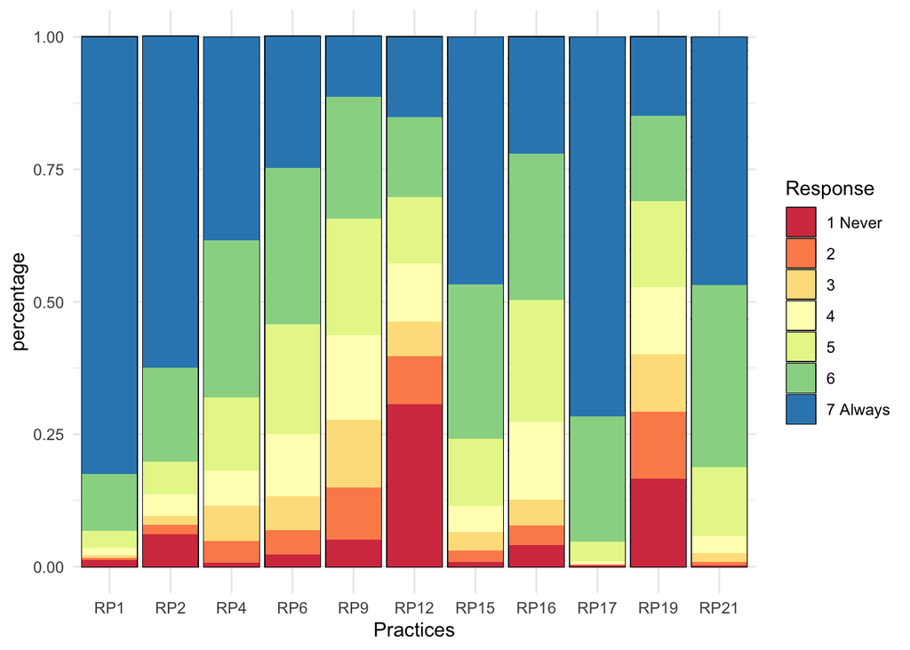

```r
mice::complete(imp, 1) %>% #RRP has no missings -so use 1st imputed set
  select(all_of(RRP_set)) %>%
  na_if(0) %>%
  sapply(p_tab) %>%
  melt(varnames = c("Response", "Practices")) %>%
  mutate(Response = factor(Response),
         percentage = value,
         Response = recode(Response, `1` = "1 Never", `7` = "7 Always")) %>%
  ggplot(aes(x = Practices, y = percentage, fill = Response)) +
  geom_bar(stat = 'identity', position = "stack", colour="black") +
  geom_col(position = position_stack(reverse = TRUE)) +
  scale_fill_brewer(palette = "Spectral") +
  theme_minimal()
```

### By Disciplinary Field

First, we grab the info from `D2`

```r
raw_data$D2 %>% var_label
```

```
## [1] "D2: Which of the following is your main disciplinary field of research?"
```

```r
raw_data$D2 %>% val_labels
```

```
##   Social and Behavioral Sciences              Arts and Humanities
##                                1                                2
## Engineering and Natural Sciences     Biomedical and Life Sciences
##                                3                                4
```

Then we calculate a table for each of the labels in `D2`

```r
out <- mice::complete(imp, 1) %>%
  select(D2, all_of(RRP_set)) %>%
  na_if(0) %>%
  mutate(across(where(is.numeric), as.factor)) %>%
  group_by(D2) %>%
  group_map(~sapply(., table, simplify = TRUE))
names(out) <- raw_data$D2 %>% val_labels %>% names
out
```

```
## $`Social and Behavioral Sciences`
##    RP1 RP2 RP4 RP6 RP9 RP12 RP15 RP16 RP17 RP19 RP21
## 1   23  73  11  49  75  461   18  103    3  323    2
## 2    9  14  64  95 189  114   37   68    3  196   10
## 3   10  18 115 120 234   80   56   72    1  132   24
## 4   22  41 100 229 282  155   88  231    6  169   62
## 5   61  53 242 325 419  209  221  417   76  200  277
## 6  180 160 481 449 416  162  471  489  400  178  665
## 7 1363 521 814 413 179  145  879  359 1431  202  831
##
## $`Arts and Humanities`
##   RP1 RP2 RP4 RP6 RP9 RP12 RP15 RP16 RP17 RP19 RP21
## 1  10  14   0   8  36   82    5   35    1   37    1
## 2   6  12  11  13  42   16    9   30    0   27    4
## 3   5   5  11  15  60   16   22   52    0   11   10
```

[output cut: 24 more lines]

Then we calculate the proportional table

```r
p.out <- mice::complete(imp, 1) %>%
  select(D2, all_of(RRP_set)) %>%
  na_if(0) %>%
  mutate(across(where(is.numeric), as.factor)) %>%
  group_by(D2) %>%
  group_map(~sapply(., p_tab, simplify = TRUE))
names(p.out) <- names(out)
p.out
```

```
## $`Social and Behavioral Sciences`
##     RP1   RP2   RP4   RP6   RP9  RP12  RP15  RP16  RP17  RP19  RP21
## 1 0.014 0.083 0.006 0.029 0.042 0.348 0.010 0.059 0.002 0.231 0.001
## 2 0.005 0.016 0.035 0.057 0.105 0.086 0.021 0.039 0.002 0.140 0.005
## 3 0.006 0.020 0.063 0.071 0.130 0.060 0.032 0.041 0.001 0.094 0.013
## 4 0.013 0.047 0.055 0.136 0.157 0.117 0.050 0.133 0.003 0.121 0.033
## 5 0.037 0.060 0.132 0.193 0.234 0.158 0.125 0.240 0.040 0.143 0.148
## 6 0.108 0.182 0.263 0.267 0.232 0.122 0.266 0.281 0.208 0.127 0.355
## 7 0.817 0.592 0.446 0.246 0.100 0.109 0.497 0.206 0.745 0.144 0.444
##
## $`Arts and Humanities`
##     RP1   RP2   RP4   RP6   RP9  RP12  RP15  RP16  RP17  RP19  RP21
## 1 0.023 0.046 0.000 0.017 0.076 0.400 0.013 0.062 0.002 0.180 0.002
## 2 0.014 0.039 0.022 0.028 0.089 0.078 0.023 0.053 0.000 0.131 0.007
## 3 0.011 0.016 0.022 0.033 0.127 0.078 0.056 0.092 0.000 0.053 0.017
```

[output cut: 24 more lines]

And the plots

```
## $`Social and Behavioral Sciences`
```

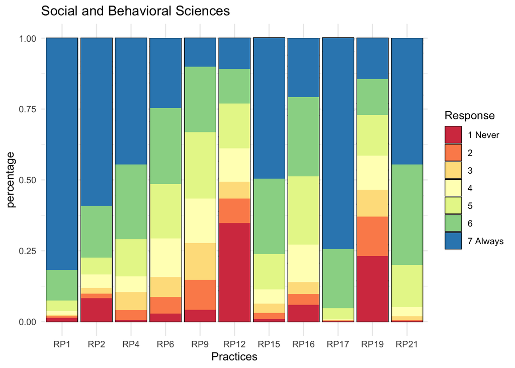

```
##
## $`Arts and Humanities`
```

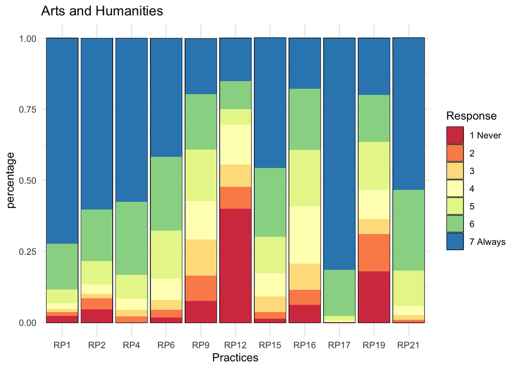

```
##
## $`Engineering and Natural Sciences`
```

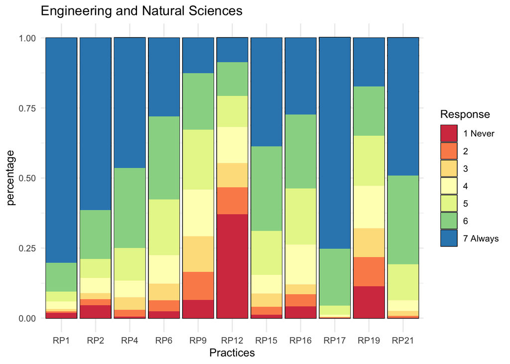

```
##
## $`Biomedical and Life Sciences`
```

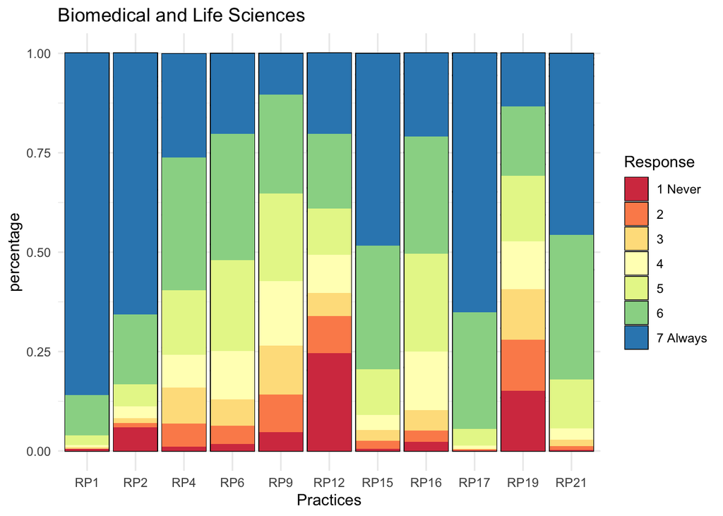

```r
barplotfun <- function(data){
  current <- sapply(p.out, function(x){identical(x, data)}) %>% which %>% names
  data %>%
    melt(varnames = c("Response", "Practices")) %>%
    mutate(Response = factor(Response),
           percentage = value / (sum(value)/11),
           Response = recode(Response, `1` = "1 Never", `7` = "7 Always")) %>%
    ggplot(aes(x = Practices, y = percentage, fill = Response)) +
    geom_bar(stat = 'identity', position = "stack", colour="black") +
    geom_col(position = position_stack(reverse = TRUE)) +
    scale_fill_brewer(palette = "Spectral") +
    theme_minimal() +
    ggtitle(current)
}
lapply(p.out, barplotfun)
```

### By academic rank

First, we grab the info from `D3`

```r
raw_data$D3 %>% var_label
```

```
## [1] "D3: Which academic rank do you belong to?"
```

```r
raw_data$D3 %>% val_labels
```

```
##                                                          PhD student or junior researcher
##                                                                                         1
## Postdoctoral researcher, Assistant Professor, Physician Researcher or Lecturer Researcher
##                                                                                         2
##                                                     Associate Professor or Full Professor
##                                                                                         3
##                                                                         None of the above
##                                                                                         4
```

Then we calculate a table for each of the labels in `D3`

```r
out <- mice::complete(imp, 1) %>%
  select(D3, all_of(RRP_set)) %>%
  na_if(0) %>%
  mutate(across(where(is.numeric), as.factor)) %>%
  group_by(D3) %>%
  group_map(~sapply(., table, simplify = TRUE))
names(out) <- raw_data$D3 %>% val_labels %>% names %>% .[1:3]
out
```

```
## $`PhD student or junior researcher`
##    RP1 RP2 RP4 RP6 RP9 RP12 RP15 RP16 RP17 RP19 RP21
## 1   35  48  24  37  49  370   13  117    2  287    4
## 2   11  13 110  76 137   89   19   57    1  149   11
## 3   14  13 163 100 219   75   54   59    4  135   25
## 4   32  34 143 171 280  109   79  141   15  130   62
## 5   60  69 255 301 458  133  250  208  109  143  266
## 6  152 190 415 436 436  160  535  270  471  158  592
## 7 1221 522 598 430 232  219  834  576 1235  215  839
##
## $`Postdoctoral researcher, Assistant Professor, Physician Researcher or Lecturer Researcher`
##    RP1 RP2 RP4 RP6 RP9 RP12 RP15 RP16 RP17 RP19 RP21
## 1   21  97  20  64 108  555   20  100    6  365    8
## 2    8  23 122 114 257  165   59  102    8  257   20
## 3   12  31 204 153 319  111   94  140    4  239   36
## 4   27  68 189 318 409  192  127  395   15  259   87
## 5   80  92 402 528 558  231  292  662   87  365  355
## 6  252 251 779 700 574  229  690  745  616  339  914
## 7 2105 855 911 582 280  222 1198  492 1960  292 1259
##
## $`Associate Professor or Full Professor`
##    RP1 RP2 RP4 RP6 RP9 RP12 RP15 RP16 RP17 RP19 RP21
## 1   14  64   3  33 158  353   22   34    2  169    0
## 2    7  24  31  81 210  122   56   67    2  216   16
## 3    7  13  61 123 236   85   61   99    1  162   41
## 4   19  36  88 205 289  156   99  360    5  237   62
## 5   50  52 218 393 328  160  227  536   50  292  235
## 6  234 167 691 601 395  241  541  672  468  297  735
## 7 1566 762 920 450 185  189  789  274 1519  228  947
```

Then we calculate the proportional table

```r
p.out <- mice::complete(imp, 1) %>%
  select(D3, all_of(RRP_set)) %>%
  na_if(0) %>%
  mutate(across(where(is.numeric), as.factor)) %>%
  group_by(D3) %>%
  group_map(~sapply(., p_tab, simplify = TRUE))
names(p.out) <- names(out)
p.out
```

```
## $`PhD student or junior researcher`
##     RP1   RP2   RP4   RP6   RP9  RP12  RP15  RP16  RP17  RP19  RP21
## 1 0.023 0.054 0.014 0.024 0.027 0.320 0.007 0.082 0.001 0.236 0.002
## 2 0.007 0.015 0.064 0.049 0.076 0.077 0.011 0.040 0.001 0.122 0.006
## 3 0.009 0.015 0.095 0.064 0.121 0.065 0.030 0.041 0.002 0.111 0.014
## 4 0.021 0.038 0.084 0.110 0.155 0.094 0.044 0.099 0.008 0.107 0.034
## 5 0.039 0.078 0.149 0.194 0.253 0.115 0.140 0.146 0.059 0.118 0.148
## 6 0.100 0.214 0.243 0.281 0.241 0.139 0.300 0.189 0.256 0.130 0.329
## 7 0.801 0.587 0.350 0.277 0.128 0.190 0.467 0.403 0.672 0.177 0.466
##
## $`Postdoctoral researcher, Assistant Professor, Physician Researcher or Lecturer Researcher`
##     RP1   RP2   RP4   RP6   RP9  RP12  RP15  RP16  RP17  RP19  RP21
## 1 0.008 0.068 0.008 0.026 0.043 0.326 0.008 0.038 0.002 0.172 0.003
## 2 0.003 0.016 0.046 0.046 0.103 0.097 0.024 0.039 0.003 0.121 0.007
## 3 0.005 0.022 0.078 0.062 0.127 0.065 0.038 0.053 0.001 0.113 0.013
## 4 0.011 0.048 0.072 0.129 0.163 0.113 0.051 0.150 0.006 0.122 0.032
## 5 0.032 0.065 0.153 0.215 0.223 0.135 0.118 0.251 0.032 0.172 0.133
## 6 0.101 0.177 0.297 0.285 0.229 0.134 0.278 0.283 0.228 0.160 0.341
## 7 0.840 0.603 0.347 0.237 0.112 0.130 0.483 0.187 0.727 0.138 0.470
##
## $`Associate Professor or Full Professor`
##     RP1   RP2   RP4   RP6   RP9  RP12  RP15  RP16  RP17  RP19  RP21
## 1 0.007 0.057 0.001 0.017 0.088 0.270 0.012 0.017 0.001 0.106 0.000
## 2 0.004 0.021 0.015 0.043 0.117 0.093 0.031 0.033 0.001 0.135 0.008
## 3 0.004 0.012 0.030 0.065 0.131 0.065 0.034 0.048 0.000 0.101 0.020
## 4 0.010 0.032 0.044 0.109 0.160 0.119 0.055 0.176 0.002 0.148 0.030
## 5 0.026 0.047 0.108 0.208 0.182 0.123 0.126 0.262 0.024 0.182 0.115
## 6 0.123 0.149 0.343 0.319 0.219 0.185 0.301 0.329 0.229 0.186 0.361
## 7 0.826 0.682 0.457 0.239 0.103 0.145 0.440 0.134 0.742 0.142 0.465
```

And the plots

```
## $`PhD student or junior researcher`
```

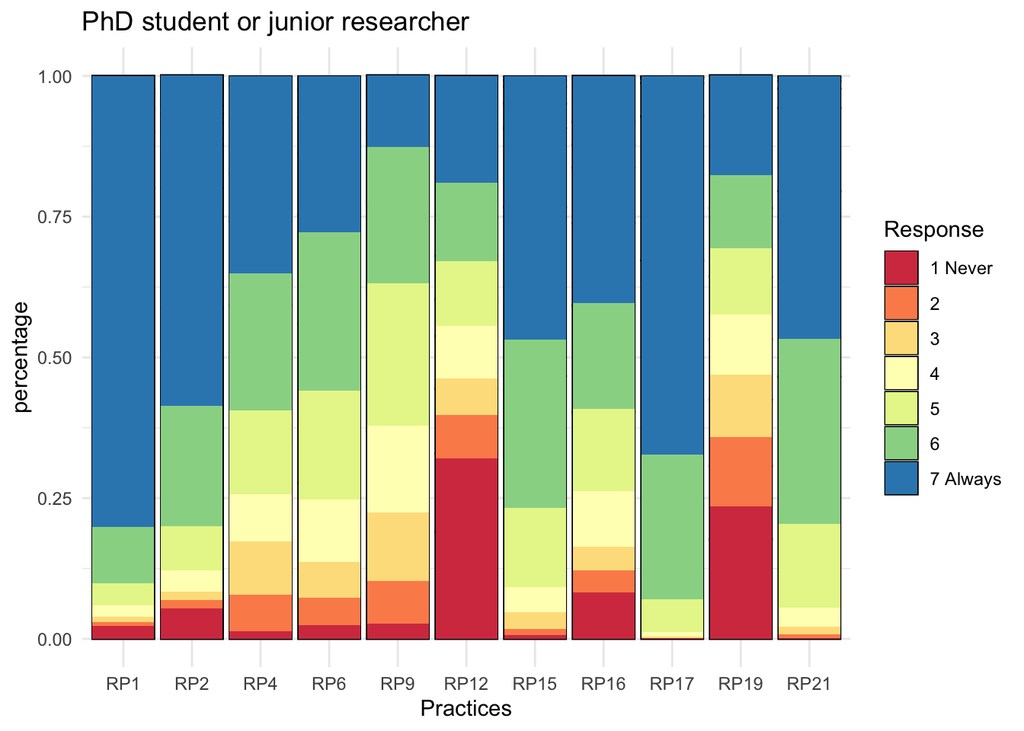

```
##
## $`Postdoctoral researcher, Assistant Professor, Physician Researcher or Lecturer Researcher`
```

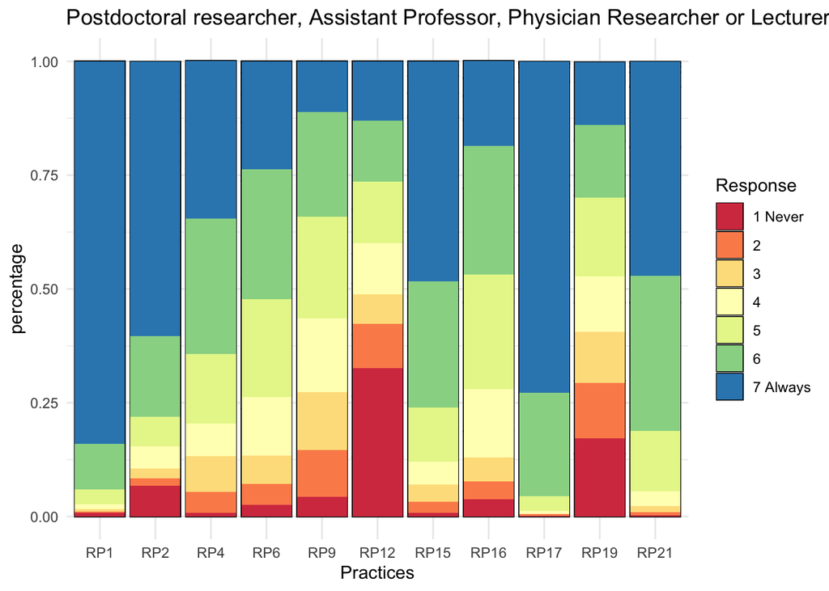

```
##
## $`Associate Professor or Full Professor`
```

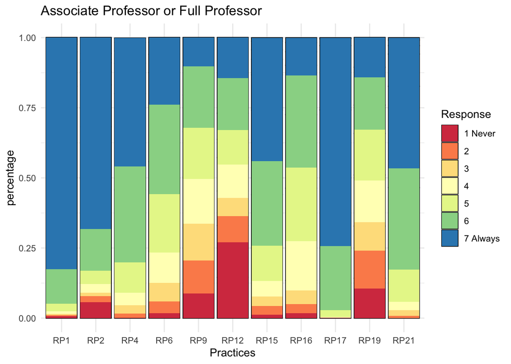

```r
lapply(p.out, barplotfun)
```

### By gender identification

First, we grab the info from `D4`

```r
raw_data$D4 %>% var_label
```

```
## [1] "D4: What is your gender?"
```

```r
raw_data$D4 %>% val_labels
```

```
##                          Female                            Male
##                               1                               2
## Other / Do not wish to disclose
##                               3
```

Then we calculate a table for each of the labels in `D4`

```r
out <- mice::complete(imp, 1) %>%
  select(D4, all_of(RRP_set)) %>%
  na_if(0) %>%
  mutate(across(where(is.numeric), as.factor)) %>%
  group_by(D4) %>%
  group_map(~sapply(., table, simplify = TRUE))
names(out) <- raw_data$D4 %>% val_labels %>% names
out
```

```
## $Female
##    RP1 RP2 RP4 RP6 RP9 RP12 RP15 RP16 RP17 RP19 RP21
## 1   30  68  25  40  86  517   17  111    5  418    3
## 2    7  25 139 127 212  163   47   94    9  306   21
## 3   16  28 258 189 321  139   78  126    4  259   34
## 4   31  54 229 339 438  209  133  354   18  250   84
## 5   80  82 428 540 677  246  340  575  118  308  382
## 6  281 255 778 732 675  297  773  714  692  270  963
## 7 2134 865 903 588 324  317 1327  611 2017  256 1348
##
## $Male
##    RP1  RP2  RP4 RP6 RP9 RP12 RP15 RP16 RP17 RP19 RP21
## 1   38  140   22  90 223  739   36  136    5  390    8
## 2   19   35  116 141 386  208   85  130    2  314   26
## 3   17   29  163 185 439  129  130  170    5  270   65
## 4   47   81  183 343 527  240  167  523   17  369  122
## 5  105  127  432 666 646  273  417  806  126  479  452
## 6  350  344 1082 982 705  327  977  940  842  511 1253
## 7 2671 1224 1480 841 356  303 1441  711 2607  458 1640
##
## $`Other / Do not wish to disclose`
##   RP1 RP2 RP4 RP6 RP9 RP12 RP15 RP16 RP17 RP19 RP21
## 1   2   1   0   4   6   22    2    4    0   13    1
## 2   0   0   8   3   6    5    2    2    0    2    0
## 3   0   0   7   2  14    3    1    2    0    7    3
## 4   0   3   8  12  13    8    5   19    0    7    5
## 5   5   4  15  16  21    5   12   25    2   13   22
## 6   7   9  25  23  25    6   16   33   21   13   25
## 7  87  50  46  33  17   10   53   20   90   21   57
```

Then we calculate the proportional table

```r
p.out <- mice::complete(imp, 1) %>%
  select(D4, all_of(RRP_set)) %>%
  na_if(0) %>%
  mutate(across(where(is.numeric), as.factor)) %>%
  group_by(D4) %>%
  group_map(~sapply(., p_tab, simplify = TRUE))
names(p.out) <- names(out)
p.out
```

```
## $Female
##     RP1   RP2   RP4   RP6   RP9  RP12  RP15  RP16  RP17  RP19  RP21
## 1 0.012 0.049 0.009 0.016 0.031 0.274 0.006 0.043 0.002 0.202 0.001
## 2 0.003 0.018 0.050 0.050 0.078 0.086 0.017 0.036 0.003 0.148 0.007
## 3 0.006 0.020 0.093 0.074 0.117 0.074 0.029 0.049 0.001 0.125 0.012
## 4 0.012 0.039 0.083 0.133 0.160 0.111 0.049 0.137 0.006 0.121 0.030
## 5 0.031 0.060 0.155 0.211 0.248 0.130 0.125 0.222 0.041 0.149 0.135
## 6 0.109 0.185 0.282 0.286 0.247 0.157 0.285 0.276 0.242 0.131 0.340
## 7 0.827 0.628 0.327 0.230 0.119 0.168 0.489 0.236 0.705 0.124 0.475
##
## $Male
##     RP1   RP2   RP4   RP6   RP9  RP12  RP15  RP16  RP17  RP19  RP21
## 1 0.012 0.071 0.006 0.028 0.068 0.333 0.011 0.040 0.001 0.140 0.002
## 2 0.006 0.018 0.033 0.043 0.118 0.094 0.026 0.038 0.001 0.113 0.007
## 3 0.005 0.015 0.047 0.057 0.134 0.058 0.040 0.050 0.001 0.097 0.018
## 4 0.014 0.041 0.053 0.106 0.161 0.108 0.051 0.153 0.005 0.132 0.034
## 5 0.032 0.064 0.124 0.205 0.197 0.123 0.128 0.236 0.035 0.172 0.127
## 6 0.108 0.174 0.311 0.302 0.215 0.147 0.300 0.275 0.234 0.183 0.351
## 7 0.823 0.618 0.426 0.259 0.108 0.137 0.443 0.208 0.723 0.164 0.460
##
## $`Other / Do not wish to disclose`
##     RP1   RP2   RP4   RP6   RP9  RP12  RP15  RP16  RP17  RP19  RP21
## 1 0.020 0.015 0.000 0.043 0.059 0.373 0.022 0.038 0.000 0.171 0.009
## 2 0.000 0.000 0.073 0.032 0.059 0.085 0.022 0.019 0.000 0.026 0.000
## 3 0.000 0.000 0.064 0.022 0.137 0.051 0.011 0.019 0.000 0.092 0.027
## 4 0.000 0.045 0.073 0.129 0.127 0.136 0.055 0.181 0.000 0.092 0.044
## 5 0.050 0.060 0.138 0.172 0.206 0.085 0.132 0.238 0.018 0.171 0.195
## 6 0.069 0.134 0.229 0.247 0.245 0.102 0.176 0.314 0.186 0.171 0.221
## 7 0.861 0.746 0.422 0.355 0.167 0.169 0.582 0.190 0.796 0.276 0.504
```

And the plots

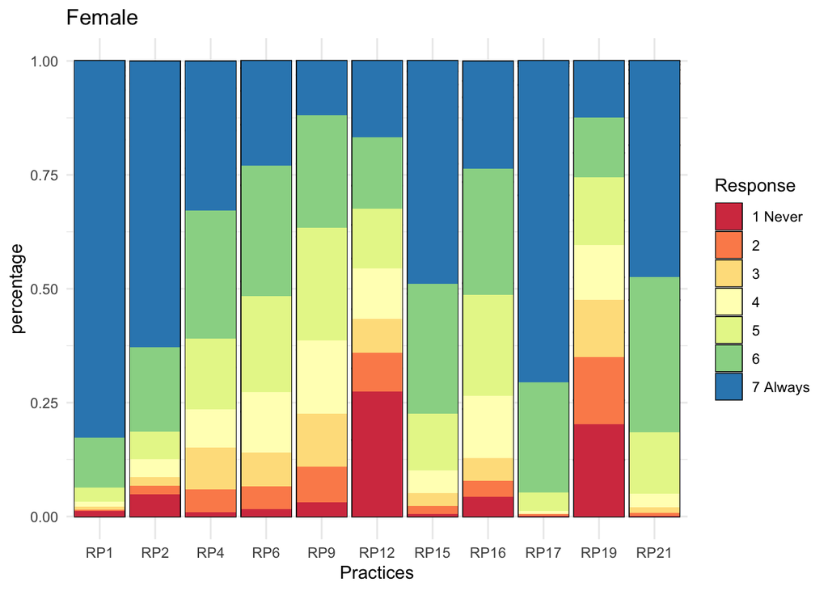

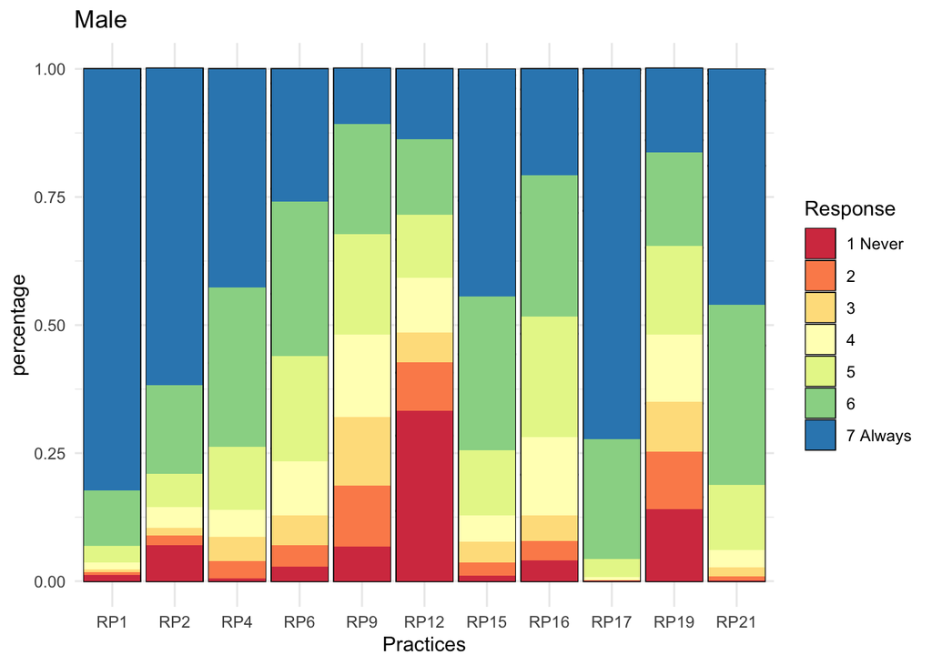

```
##
## $`Other / Do not wish to disclose`
```

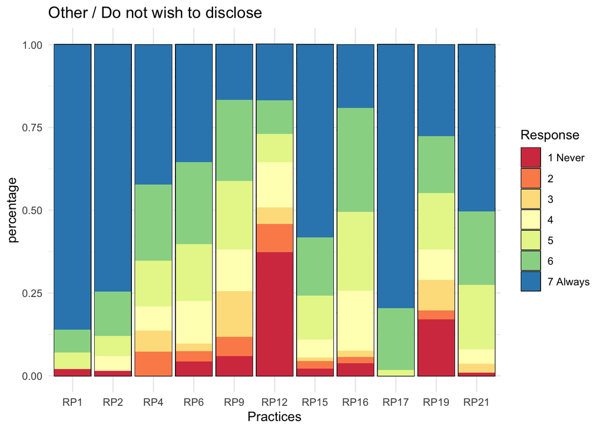

```r
lapply(p.out, barplotfun)
```

### By empirical research engagement

First, we grab the info from `D5`

```r
raw_data$D5 %>% var_label
```

```
## [1] "D5: Were you engaged in empirical research in the last three years?"
```

```r
raw_data$D5 %>% val_labels
```

```
## Yes  No
##   1   2
```

Then we calculate a table for each of the labels in `D5`

```r
out <- mice::complete(imp, 1) %>%
  select(D5, all_of(RRP_set)) %>%
  na_if(0) %>%
  mutate(across(where(is.numeric), as.factor)) %>%
  group_by(D5) %>%
  group_map(~sapply(., table, simplify = TRUE))
names(out) <- raw_data$D5 %>% val_labels %>% names
out
```

```
## $Yes
##    RP1  RP2  RP4  RP6  RP9 RP12 RP15 RP16 RP17 RP19 RP21
## 1   48  191   41  123  263 1198   46  200    9  791    9
## 2   16   52  250  260  552  356  120  181    9  589   42
## 3   29   47  408  360  719  258  185  262    8  511   98
## 4   64  124  390  648  904  422  284  787   30  588  185
## 5  166  183  817 1136 1231  506  707 1281  220  748  782
## 6  578  533 1753 1605 1303  609 1659 1562 1415  730 2043
## 7 4509 1915 2108 1267  618  602 2679 1211 4198  660 2704
##
## $No
##   RP1 RP2 RP4 RP6 RP9 RP12 RP15 RP16 RP17 RP19 RP21
## 1  22  18   6  11  52   80    9   51    1   30    3
## 2  10   8  13  11  52   20   14   45    2   33    5
## 3   4  10  20  16  55   13   24   36    1   25    4
## 4  14  14  30  46  74   35   21  109    5   38   26
## 5  24  30  58  86 113   18   62  125   26   52   74
## 6  60  75 132 132 102   21  107  125  140   64  198
## 7 383 224 321 195  79   28  142  131  516   75  341
```

Then we calculate the proportional table

```r
p.out <- mice::complete(imp, 1) %>%
  select(D5, all_of(RRP_set)) %>%
  na_if(0) %>%
  mutate(across(where(is.numeric), as.factor)) %>%
  group_by(D5) %>%
  group_map(~sapply(., p_tab, simplify = TRUE))
names(p.out) <- names(out)
p.out
```

```
## $Yes
##     RP1   RP2   RP4   RP6   RP9  RP12  RP15  RP16  RP17  RP19  RP21
## 1 0.009 0.063 0.007 0.023 0.047 0.303 0.008 0.036 0.002 0.171 0.002
## 2 0.003 0.017 0.043 0.048 0.099 0.090 0.021 0.033 0.002 0.128 0.007
## 3 0.005 0.015 0.071 0.067 0.129 0.065 0.033 0.048 0.001 0.111 0.017
## 4 0.012 0.041 0.068 0.120 0.162 0.107 0.050 0.144 0.005 0.127 0.032
## 5 0.031 0.060 0.142 0.210 0.220 0.128 0.124 0.234 0.037 0.162 0.133
## 6 0.107 0.175 0.304 0.297 0.233 0.154 0.292 0.285 0.240 0.158 0.348
## 7 0.833 0.629 0.366 0.235 0.111 0.152 0.472 0.221 0.713 0.143 0.461
##
## $No
##     RP1   RP2   RP4   RP6   RP9  RP12  RP15  RP16  RP17  RP19  RP21
## 1 0.043 0.047 0.010 0.022 0.099 0.372 0.024 0.082 0.001 0.095 0.005
## 2 0.019 0.021 0.022 0.022 0.099 0.093 0.037 0.072 0.003 0.104 0.008
## 3 0.008 0.026 0.034 0.032 0.104 0.060 0.063 0.058 0.001 0.079 0.006
## 4 0.027 0.037 0.052 0.093 0.140 0.163 0.055 0.175 0.007 0.120 0.040
## 5 0.046 0.079 0.100 0.173 0.214 0.084 0.164 0.201 0.038 0.164 0.114
## 6 0.116 0.198 0.228 0.266 0.194 0.098 0.282 0.201 0.203 0.202 0.304
## 7 0.741 0.591 0.553 0.392 0.150 0.130 0.375 0.211 0.747 0.237 0.524
```

And the plots

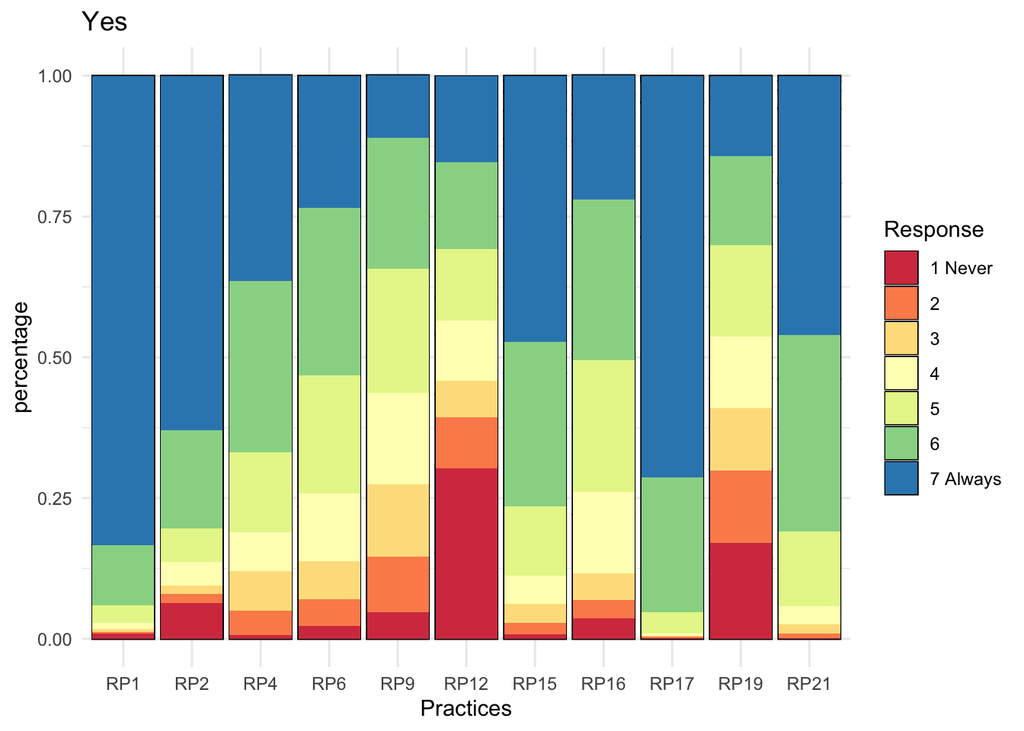

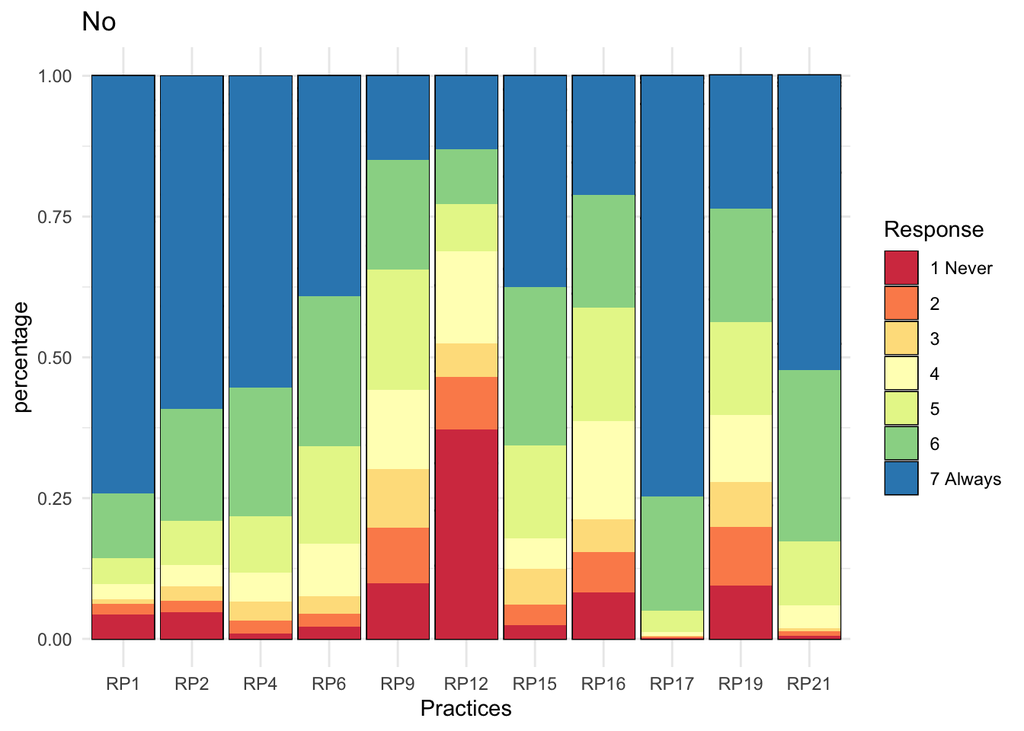

```r
lapply(p.out, barplotfun)
```

### By institutional support

First, we grab the info from `Group`

```r
raw_data$Group %>% var_label
```

```
## [1] "Group"
```

```r
raw_data$Group %>% val_labels
```

```
##     Joining group Non-joining group
##                 1                 2
```

Then we calculate a table for each of the labels in `Group`

```r
out <- mice::complete(imp, 1) %>%
  select(Group, all_of(RRP_set)) %>%
  na_if(0) %>%
  mutate(across(where(is.numeric), as.factor)) %>%
  group_by(Group) %>%
  group_map(~sapply(., table, simplify = TRUE))
names(out) <- raw_data$Group %>% val_labels %>% names
out
```

```
## $`Joining group`
##    RP1 RP2  RP4 RP6 RP9 RP12 RP15 RP16 RP17 RP19 RP21
## 1   30  89   30  68 135  563   23  140    6  415    7
## 2   12  28  145 142 272  171   53  112    8  312   16
## 3   11  21  247 177 380  129   90  151    5  262   49
## 4   32  59  218 352 482  213  147  422   22  264  101
## 5   81  91  436 580 685  295  358  630  120  341  441
## 6  290 284  888 828 703  338  859  763  758  366 1052
## 7 2331 992 1056 649 295  378 1380  613 2206  309 1422
##
## $`Non-joining group`
##    RP1  RP2  RP4 RP6 RP9 RP12 RP15 RP16 RP17 RP19 RP21
## 1   40  120   17  66 180  715   32  111    4  406    5
## 2   14   32  118 129 332  205   81  114    3  310   31
## 3   22   36  181 199 394  142  119  147    4  274   53
## 4   46   79  202 342 496  244  158  474   13  362  110
## 5  109  122  439 642 659  229  411  776  126  459  415
## 6  348  324  997 909 702  292  907  924  797  428 1189
## 7 2561 1147 1373 813 402  252 1441  729 2508  426 1623
```

Then we calculate the proportional table

```r
p.out <- mice::complete(imp, 1) %>%
  select(Group, all_of(RRP_set)) %>%
  na_if(0) %>%
  mutate(across(where(is.numeric), as.factor)) %>%
  group_by(Group) %>%
  group_map(~sapply(., p_tab, simplify = TRUE))
names(p.out) <- names(out)
p.out
```

```
## $`Joining group`
##     RP1   RP2   RP4   RP6   RP9  RP12  RP15  RP16  RP17  RP19  RP21
## 1 0.011 0.057 0.010 0.024 0.046 0.270 0.008 0.049 0.002 0.183 0.002
## 2 0.004 0.018 0.048 0.051 0.092 0.082 0.018 0.040 0.003 0.138 0.005
## 3 0.004 0.013 0.082 0.063 0.129 0.062 0.031 0.053 0.002 0.115 0.016
## 4 0.011 0.038 0.072 0.126 0.163 0.102 0.051 0.149 0.007 0.116 0.033
## 5 0.029 0.058 0.144 0.207 0.232 0.141 0.123 0.223 0.038 0.150 0.143
## 6 0.104 0.182 0.294 0.296 0.238 0.162 0.295 0.270 0.243 0.161 0.341
## 7 0.836 0.634 0.350 0.232 0.100 0.181 0.474 0.217 0.706 0.136 0.460
##
## $`Non-joining group`
##     RP1   RP2   RP4   RP6   RP9  RP12  RP15  RP16  RP17  RP19  RP21
## 1 0.013 0.065 0.005 0.021 0.057 0.344 0.010 0.034 0.001 0.152 0.001
## 2 0.004 0.017 0.035 0.042 0.105 0.099 0.026 0.035 0.001 0.116 0.009
## 3 0.007 0.019 0.054 0.064 0.124 0.068 0.038 0.045 0.001 0.103 0.015
## 4 0.015 0.042 0.061 0.110 0.157 0.117 0.050 0.145 0.004 0.136 0.032
## 5 0.035 0.066 0.132 0.207 0.208 0.110 0.131 0.237 0.036 0.172 0.121
## 6 0.111 0.174 0.300 0.293 0.222 0.140 0.288 0.282 0.231 0.161 0.347
## 7 0.816 0.617 0.413 0.262 0.127 0.121 0.458 0.223 0.726 0.160 0.474
```

And the plots

```
## $`Joining group`
```

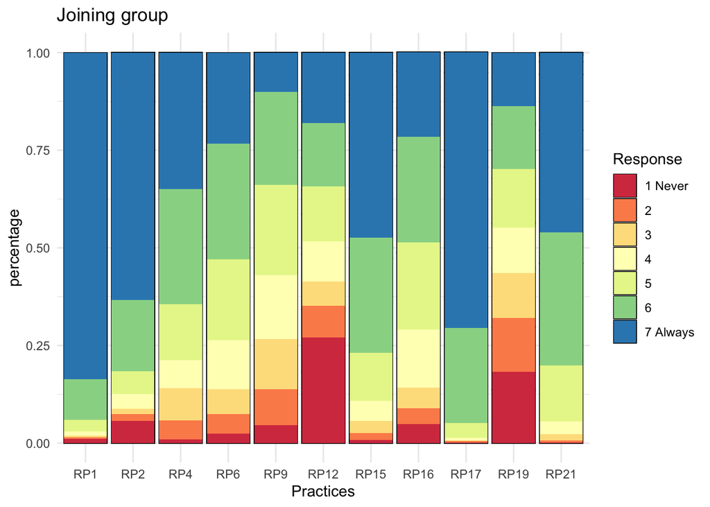

```
##
## $`Non-joining group`
```

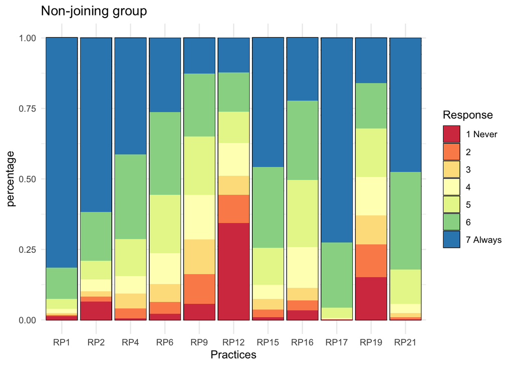

```r
lapply(p.out, barplotfun)
```

# Document info

Signed: [Gerko Vink](https://www.gerkovink.com),

```r
timestamp()
```

```
## ##------ Tue Apr 13 21:58:00 2021 ------##
```

END of DOCUMENT